# Logistic regression

Jarad Niemi

2023-04-03

R code

```r
library("tidyverse"); theme_set(theme_bw())
library("Sleuth3")
library("ggResidpanel")
library("emmeans")
```

# Logistic Regression

## Model

Let $Y_i$ be a Bernoulli response variable. Assume
$$Y_i \stackrel{ind}{\sim} Ber(\theta_i), \quad
\eta_i = \mbox{logit}(\theta_i) = \log\left(\frac{\theta_i}{1-\theta_i}
\right) =
\beta_0 + \beta_1X_{i,1} + \cdots + \beta_{p-1} X_{i,p-1}$$
where $\frac{\theta_i}{1-\theta_i}$ is the *odds*.

Sometimes observations can be grouped according to common explanatory varaible values. When this is the case, the model can be written using a binomial distribution:
$$Y_i \stackrel{ind}{\sim} Bin(n_i,\theta_i), \quad
\mbox{logit}(\theta_i) = \log\left(\frac{\theta_i}{1-\theta_i} \right) =
\beta_0 + \beta_1X_{i,1} + \cdots + \beta_{p-1} X_{i,p-1}$$
Remember that a binomial is simply the sum of a set of Bernoulli random variables that and **independent** and have the same probability of success. Thus these two models are equivalent.

The inverse of the logitic, i.e. logit, function will be used later:

```r
expit <- function(eta) 1/(1+exp(-eta)) # inverse logitistic
```

### glm()

In R, you can fit these models both ways. The following data set is recorded in a grouped fashion.

```r
case1802
```

```
##   Treatment Cold NoCold
## 1   Placebo  335     76
## 2      VitC  302    105
```

Thus, it is natural to fit binomial model

```r
# NoCold is success here
m_binomial <- glm(cbind(NoCold, Cold) ~ Treatment,
                  data = case1802,
                  family = "binomial")
```

Let’s wrangle the data into the other format.

```r
case1802_individual <- case1802 %>%
  tidyr::pivot_longer(-Treatment, names_to = "Result", values_to = "n") %>%
  tidyr::uncount(n) %>%
  mutate(Result = factor(Result))

table(case1802_individual)
```

```
##          Result
## Treatment Cold NoCold
##   Placebo  335     76
##   VitC     302    105
```

Now we can analyze this data set

```r
m_bernoulli <- glm(Result ~ Treatment,
                   data = case1802_individual,
                   family = "binomial")
```

## Parameter estimation

The maximum likelihood estimator for this model is not available in closed form and thus we use an iterative algorithm to find the answers. But we don’t have to worry about these details.

```r
coef(m_bernoulli)
```

```
##   (Intercept) TreatmentVitC
##    -1.4833972     0.4269305
```

This MLE can be used to determine asymptotic confidence intervals.

```r
confint(m_bernoulli)
```

```
##                     2.5 %     97.5 %
## (Intercept)   -1.73931608 -1.2405398
## TreatmentVitC  0.09477341  0.7628385
```

The fact that the interval for the coefficient for the dummy variable for vitamin C does not include 0 provides evidence that, if the remainder of the model is correct, that it is unlikely the coefficient is 0.

## Testing

We can also compute p-values for a single parameter being zero or a collection of parameters being zero.

```r
summary(m_bernoulli)$coefficients
```

```
##                 Estimate Std. Error    z value     Pr(>|z|)
## (Intercept)   -1.4833972  0.1270550 -11.675239 1.705863e-31
## TreatmentVitC  0.4269305  0.1702293   2.507973 1.214259e-02
```

A small p-value here indicates evidence against the model that has that coefficient equal to 0. But remember that other aspects of the model could be problematic, e.g. independence, constant probability (within a group), etc.

The p-value above is based on a Wald test. An alternative is based on a likelihood ratio test.

```r
anova(m_bernoulli, test = "LRT")
```

```
## Analysis of Deviance Table
##
## Model: binomial, link: logit
##
## Response: Result
##
## Terms added sequentially (first to last)
##
##
##           Df Deviance Resid. Df Resid. Dev Pr(>Chi)
## NULL                        817     864.65
## Treatment  1   6.3573       816     858.29  0.01169 *
## ---
## Signif. codes:  0 '***' 0.001 '**' 0.01 '*' 0.05 '.' 0.1 ' ' 1
```

Unlike with the linear regression (which is based on the normal distribution) the p-values here don’t match exactly.

## Predictions

When computing predictions, we need to be explicit about whether we want predictions on the linear part, i.e. $\eta_i$, or the response, i.e. $\theta_i = E[Y_i]$. By default, the `predict()` function provides predictions on the linear part.

```r
nd <- data.frame(Treatment = unique(case1802_individual$Treatment))

p <- nd %>%
  mutate(prediction = predict(m_bernoulli, newdata = .))
p
```

```
##   Treatment prediction
## 1   Placebo  -1.483397
## 2      VitC  -1.056467
```

We can manually compute predictions on the response.

```r
p %>% mutate(probability = expit(prediction))
```

```
##   Treatment prediction probability
## 1   Placebo  -1.483397   0.1849148
## 2      VitC  -1.056467   0.2579853
```

Alternatively, we can use `predict()` to compute these probabilities directly.

```r
p %>% mutate(probability = predict(m_bernoulli, newdata = ., type = "response"))
```

```
##   Treatment prediction probability
## 1   Placebo  -1.483397   0.1849148
## 2      VitC  -1.056467   0.2579853
```

You can also obtain standard errors which can be used to construct asymptotic confidence intervals.

```r
cbind(nd, predict(m_bernoulli, newdata = nd, se.fit = TRUE)) %>%
  mutate(
    lcl = fit - qnorm(.975)*se.fit,
    ucl = fit + qnorm(.975)*se.fit,

    # convert to probability
    prob  = expit(fit),
    p.lcl = expit(lcl),
    p.ucl = expit(ucl)
  ) %>%
  select(-residual.scale)
```

```
##   Treatment       fit    se.fit       lcl        ucl      prob     p.lcl
## 1   Placebo -1.483397 0.1270550 -1.732420 -1.2343740 0.1849148 0.1502782
## 2      VitC -1.056467 0.1132919 -1.278515 -0.8344187 0.2579853 0.2178032
##       p.ucl
## 1 0.2254168
## 2 0.3027116
```

### emmeans()

Another alternative is to use the `emmeans::emmeans()` function.

```r
emmeans(m_bernoulli, ~ Treatment, type = "response")
```

```
##  Treatment  prob     SE  df asymp.LCL asymp.UCL
##  Placebo   0.185 0.0191 Inf     0.150     0.225
##  VitC      0.258 0.0217 Inf     0.218     0.303
##
## Confidence level used: 0.95
## Intervals are back-transformed from the logit scale
```

This can also be used to perform the comparisons, e.g.

```r
emmeans(m_bernoulli, pairwise ~ Treatment, type = "response")
```

```
## $emmeans
##  Treatment  prob     SE  df asymp.LCL asymp.UCL
##  Placebo   0.185 0.0191 Inf     0.150     0.225
##  VitC      0.258 0.0217 Inf     0.218     0.303
##
## Confidence level used: 0.95
## Intervals are back-transformed from the logit scale
##
## $contrasts
##  contrast       odds.ratio    SE  df null z.ratio p.value
##  Placebo / VitC      0.653 0.111 Inf    1  -2.508  0.0121
##
## Tests are performed on the log odds ratio scale
```

The odds ratio is the simplest interpretation of a logistic regression model.

## Diagnostics

It is much more difficult to assess model assumptions in logistic regression models.

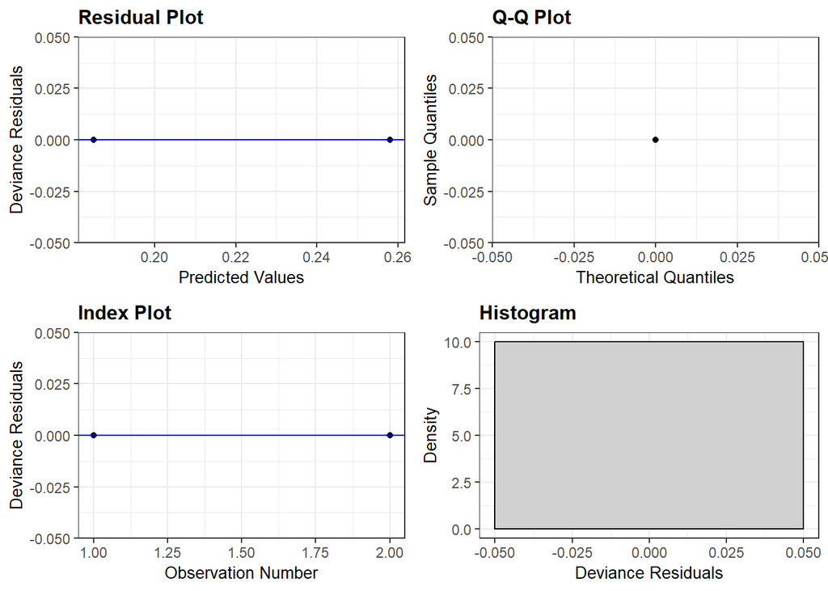

```r
resid_panel(m_binomial)
```

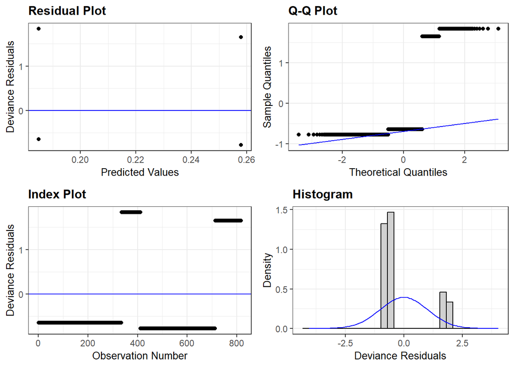

```r
resid_panel(m_bernoulli)
```

# Examples

## O-ring Failure

```r
summary(ex2011)
```

```
##   Temperature    Failure
##  Min.   :53.00   No :17
##  1st Qu.:67.00   Yes: 7
##  Median :70.00
##  Mean   :69.92
##  3rd Qu.:75.25
##  Max.   :81.00
```

```r
m <- glm(Failure ~ Temperature,
         data = ex2011,
         family = "binomial")
```

```r
summary(m)
```

```
##
## Call:
## glm(formula = Failure ~ Temperature, family = "binomial", data = ex2011)
##
## Deviance Residuals:
##     Min       1Q   Median       3Q      Max
## -1.2125  -0.8253  -0.4706   0.5907   2.0512
##
## Coefficients:
##             Estimate Std. Error z value Pr(>|z|)
## (Intercept) 10.87535    5.70291   1.907   0.0565 .
## Temperature -0.17132    0.08344  -2.053   0.0400 *
## ---
## Signif. codes:  0 '***' 0.001 '**' 0.01 '*' 0.05 '.' 0.1 ' ' 1
##
## (Dispersion parameter for binomial family taken to be 1)
##
##     Null deviance: 28.975  on 23  degrees of freedom
## Residual deviance: 23.030  on 22  degrees of freedom
## AIC: 27.03
##
## Number of Fisher Scoring iterations: 4
```

```r
p <- bind_cols(ex2011,
               predict(m, newdata = ex2011, se.fit = TRUE)) %>%
  mutate(
    lcl = fit - qnorm(.975)*se.fit,
    ucl = fit + qnorm(.975)*se.fit
  )
```

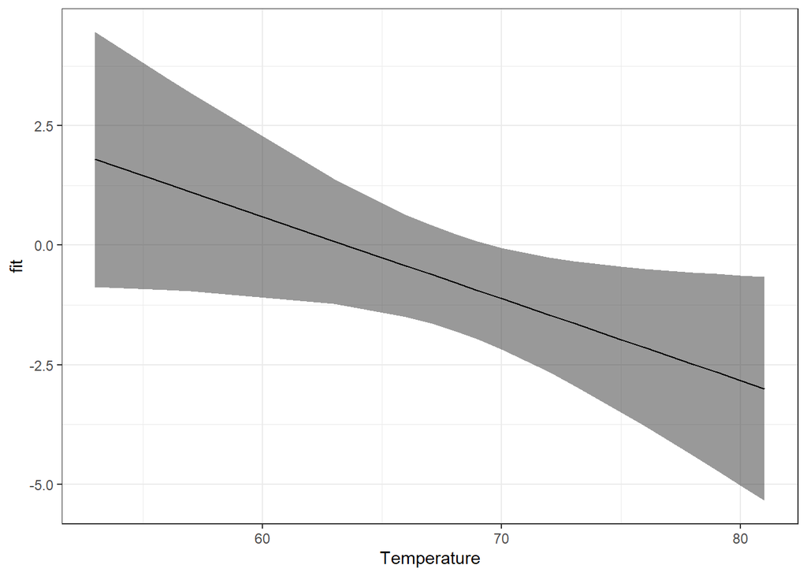

```r
ggplot(p, aes(x = Temperature, y = fit, ymin = lcl, ymax = ucl)) +
  geom_ribbon(alpha = 0.5) +
  geom_line()
```

This prediction is on the linear predictor scale, i.e. $\eta$. But this is not very interpretable. Thus, we should convert to the probability scale.

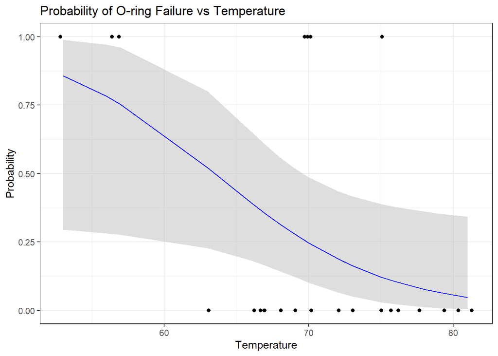

```r
p <- p %>%
  mutate(
    fit = expit(fit),
    lcl = expit(lcl),
    ucl = expit(ucl)
  )

ggplot(p, aes(x = Temperature, y = fit, ymin = lcl, ymax = ucl)) +
  geom_ribbon(alpha = 0.5, fill = "gray") +
  geom_line(color = "blue") +
  labs(
    y = "Probability",
    title = "Probability of O-ring Failure vs Temperature"
  ) +
  geom_jitter(aes(y = 1*(Failure == "Yes")),
              height = 0)
```

## Bird keeping

This analysis intends to understand the relationship between bird keeping and lung cancer. But since we know smoking is related to lung cancer, we need to adjust (or control for) smoking to understand the effect of bird keeping.

The actual data here are from a case-control study where cases are found that (in some sense) are a match to the controls.

```r
summary(case2002)
```

```
##           LC          FM         SS           BK           AG
##  LungCancer:49   Female: 36   High: 45   Bird  :67   Min.   :37.00
##  NoCancer  :98   Male  :111   Low :102   NoBird:80   1st Qu.:52.00
##                                                      Median :59.00
##                                                      Mean   :56.97
##                                                      3rd Qu.:63.00
##                                                      Max.   :67.00
##        YR              CD
##  Min.   : 0.00   Min.   : 0.00
##  1st Qu.:20.00   1st Qu.:10.00
##  Median :30.00   Median :15.00
##  Mean   :27.85   Mean   :15.75
##  3rd Qu.:39.00   3rd Qu.:20.00
##  Max.   :50.00   Max.   :45.00
```

In logistic regression models, it is often helpful to construct a binary variable so that it is clear what “success” means.

```r
d <- case2002 %>%
  mutate(LungCancer   = LC == "LungCancer",

         BirdKeeping  = ifelse(BK == "Bird", "Yes", "No"),
         BirdKeeping  = factor(BirdKeeping, levels = c("Yes","No")),

         SmokingYears = YR) %>%

  select(LungCancer, BirdKeeping, SmokingYears)

summary(d)
```

```
##  LungCancer      BirdKeeping  SmokingYears
##  Mode :logical   Yes:67      Min.   : 0.00
##  FALSE:98        No :80      1st Qu.:20.00
##  TRUE :49                    Median :30.00
##                              Mean   :27.85
##                              3rd Qu.:39.00
##                              Max.   :50.00
```

```r
m <- glm(LungCancer ~ BirdKeeping * SmokingYears,
         data = d,
         family = "binomial")
```

Attempt to assess assumptions

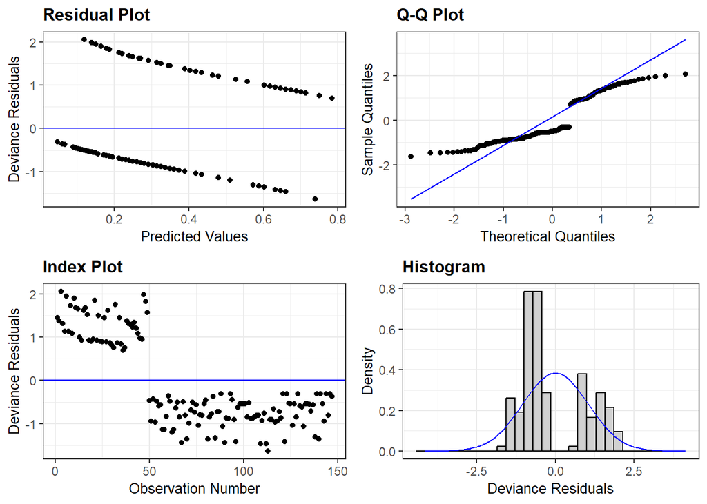

```r
resid_panel(m)
```

Model selection

```r
summary(m)
```

```
##
## Call:
## glm(formula = LungCancer ~ BirdKeeping * SmokingYears, family = "binomial",
##     data = d)
##
## Deviance Residuals:
##     Min       1Q   Median       3Q      Max
## -1.6378  -0.8497  -0.5438   0.9342   2.0604
##
## Coefficients:
##                             Estimate Std. Error z value Pr(>|z|)
## (Intercept)                -1.819393   0.712871  -2.552  0.01070 *
## BirdKeepingNo              -1.179470   1.146896  -1.028  0.30376
## SmokingYears                0.062120   0.022294   2.786  0.00533 **
## BirdKeepingNo:SmokingYears -0.009297   0.033980  -0.274  0.78440
## ---
## Signif. codes:  0 '***' 0.001 '**' 0.01 '*' 0.05 '.' 0.1 ' ' 1
##
## (Dispersion parameter for binomial family taken to be 1)
##
##     Null deviance: 187.14  on 146  degrees of freedom
## Residual deviance: 158.04  on 143  degrees of freedom
## AIC: 166.04
##
## Number of Fisher Scoring iterations: 5
```

```r
anova(m, test = "Chi")
```

```
## Analysis of Deviance Table
##
## Model: binomial, link: logit
##
## Response: LungCancer
##
## Terms added sequentially (first to last)
##
##
##                          Df Deviance Resid. Df Resid. Dev  Pr(>Chi)
## NULL                                       146     187.13
## BirdKeeping               1  14.2040       145     172.93 0.0001640 ***
## SmokingYears              1  14.8168       144     158.11 0.0001185 ***
## BirdKeeping:SmokingYears  1   0.0744       143     158.04 0.7850979
## ---
## Signif. codes:  0 '***' 0.001 '**' 0.01 '*' 0.05 '.' 0.1 ' ' 1
```

Remove interaction

```r
m <- glm(LungCancer ~ BirdKeeping + SmokingYears,
         data = d,
         family = "binomial")

summary(m)
```

```
##
## Call:
## glm(formula = LungCancer ~ BirdKeeping + SmokingYears, family = "binomial",
##     data = d)
##
## Deviance Residuals:
##     Min       1Q   Median       3Q      Max
## -1.6093  -0.8644  -0.5283   0.9479   2.0937
##
## Coefficients:
##               Estimate Std. Error z value Pr(>|z|)
## (Intercept)   -1.70460    0.56267  -3.030 0.002450 **
## BirdKeepingNo -1.47555    0.39588  -3.727 0.000194 ***
## SmokingYears   0.05825    0.01685   3.458 0.000544 ***
## ---
## Signif. codes:  0 '***' 0.001 '**' 0.01 '*' 0.05 '.' 0.1 ' ' 1
##
## (Dispersion parameter for binomial family taken to be 1)
##
##     Null deviance: 187.14  on 146  degrees of freedom
## Residual deviance: 158.11  on 144  degrees of freedom
## AIC: 164.11
##
## Number of Fisher Scoring iterations: 4
```

```r
em <- emmeans(m, pairwise ~ BirdKeeping, type = "response")
confint(em)
```

```
## $emmeans
##  BirdKeeping  prob     SE  df asymp.LCL asymp.UCL
##  Yes         0.479 0.0655 Inf     0.355     0.606
##  No          0.174 0.0440 Inf     0.104     0.277
##
## Confidence level used: 0.95
## Intervals are back-transformed from the logit scale
##
## $contrasts
##  contrast odds.ratio   SE  df asymp.LCL asymp.UCL
##  Yes / No       4.37 1.73 Inf      2.01       9.5
##
## Confidence level used: 0.95
## Intervals are back-transformed from the log odds ratio scale
```

Construct a plot to help understand the relationship between bird keeping and years of smoking on the probability of lung cancer.

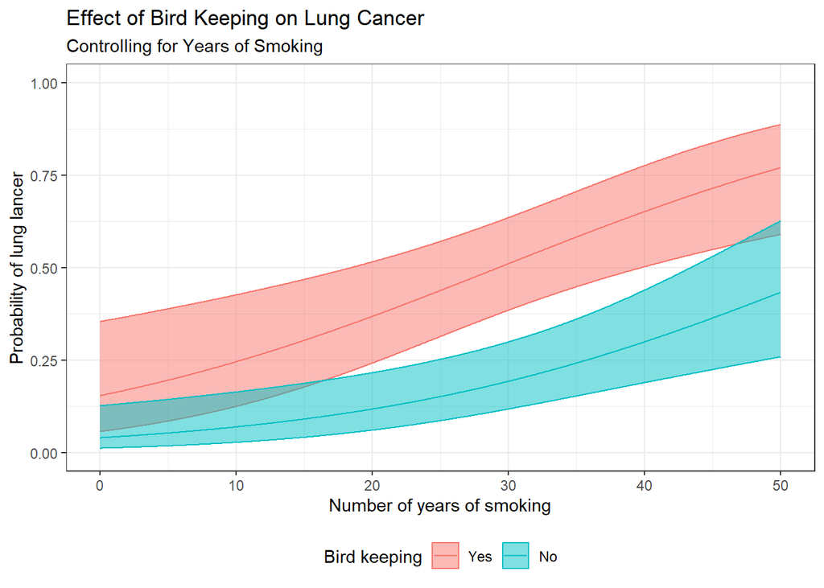

```r
nd <- expand.grid(
  BirdKeeping  = unique(d$BirdKeeping),
  SmokingYears = seq(min(d$SmokingYears), max(d$SmokingYears), length = 1001)
)

p <- bind_cols(nd, predict(m, newdata = nd, se.fit = TRUE)) %>%
  mutate(
    lcl = fit - qnorm(.975)*se.fit,
    ucl = fit + qnorm(.975)*se.fit,

    # Convert to probability scale
    prob = expit(fit),
    lcl  = expit(lcl),
    ucl  = expit(ucl)
  )

ggplot(p, aes(x = SmokingYears,
              y = prob, ymin = lcl, ymax = ucl,
              fill = BirdKeeping, color = BirdKeeping)) +
  geom_ribbon(alpha = 0.5) +
  geom_line() +
  ylim(0,1) +
  labs(y = "Probability of lung lancer",
        x = "Number of years of smoking",
        title = "Effect of Bird Keeping on Lung Cancer",
        subtitle = "Controlling for Years of Smoking",
       color = "Bird keeping",
       fill = "Bird keeping") +
  theme(legend.position = "bottom")
```

This is not necessarily the end of the analysis as there are a number of other variables in this data set that could be considered. A quick analysis suggests that maybe we have considered the most important variables.

```r
m <- glm(LC ~ ., data = case2002, family = "binomial")
drop1(m, test = "LRT")
```

```
## Single term deletions
##
## Model:
## LC ~ FM + SS + BK + AG + YR + CD
##        Df Deviance    AIC     LRT  Pr(>Chi)
## <none>      154.20 168.20
## FM      1   155.32 167.32  1.1184 0.2902721
## SS      1   154.25 166.25  0.0505 0.8221952
## BK      1   165.87 177.87 11.6700 0.0006352 ***
## AG      1   155.49 167.49  1.2961 0.2549329
## YR      1   163.93 175.93  9.7307 0.0018121 **
## CD      1   155.24 167.24  1.0420 0.3073673
## ---
## Signif. codes:  0 '***' 0.001 '**' 0.01 '*' 0.05 '.' 0.1 ' ' 1
```

## Vehicle accidents

```r
m <- glm(Cause ~ Make*Passengers*VehicleAge, data = ex2018, family = "binomial")
anova(m, test = "LRT")
```

```
## Analysis of Deviance Table
##
## Model: binomial, link: logit
##
## Response: Cause
##
## Terms added sequentially (first to last)
##
##
##                            Df Deviance Resid. Df Resid. Dev  Pr(>Chi)
## NULL                                        2320     294.20
## Make                        1   42.964      2319     251.23 5.577e-11 ***
## Passengers                  1   28.788      2318     222.44 8.075e-08 ***
## VehicleAge                  1   26.840      2317     195.60 2.210e-07 ***
## Make:Passengers             1    4.190      2316     191.41   0.04066 *
## Make:VehicleAge             1    0.713      2315     190.70   0.39841
## Passengers:VehicleAge       1    0.936      2314     189.77   0.33343
## Make:Passengers:VehicleAge  1    0.152      2313     189.61   0.69709
## ---
## Signif. codes:  0 '***' 0.001 '**' 0.01 '*' 0.05 '.' 0.1 ' ' 1
```

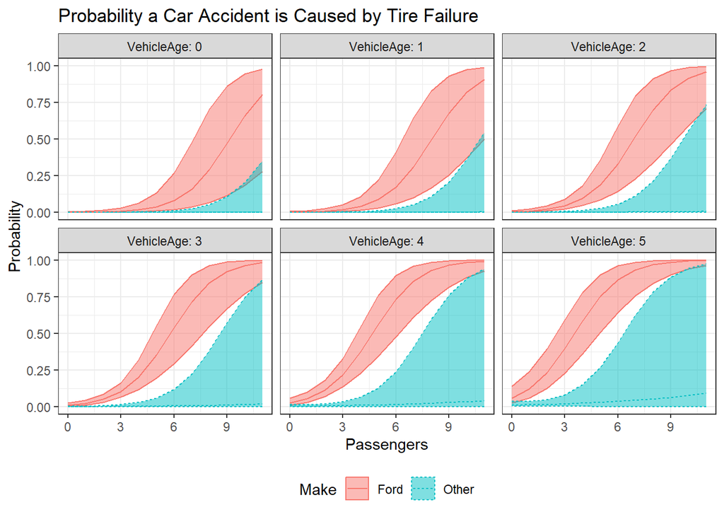

```r
m <- glm(Cause ~ Make * Passengers + VehicleAge,
         data = ex2018,
         family = "binomial")

nd <- expand.grid(
  Make  = unique(ex2018$Make),
  Passengers = seq(min(ex2018$Passengers),
                   max(ex2018$Passengers)),
  VehicleAge = seq(min(ex2018$VehicleAge),
                   max(ex2018$VehicleAge))
  )

p <- bind_cols(nd,
               predict(m, newdata = nd, se.fit = TRUE)) %>%
  mutate(
    lcl = fit - qnorm(.975)*se.fit,
    ucl = fit + qnorm(.975)*se.fit,

    fit = expit(fit),
    lcl = expit(lcl),
    ucl = expit(ucl)
  )

ggplot(p, aes(x = Passengers,
              y = fit,
              ymin = lcl,
              ymax = ucl,
              fill = Make,
              color = Make,
              linetype = Make)) +
  geom_ribbon(alpha = 0.5) +
  geom_line() +
  facet_wrap(~VehicleAge,
             labeller = label_both) +
  theme(legend.position = "bottom") +
  labs(
    y = "Probability",
    title = "Probability a Car Accident is Caused by Tire Failure"
  )
```